# A Visual History of Nobel Prize Winners

Explore a dataset from Kaggle containing a century's worth of Nobel Laureates. Who won? Who got snubbed?

## Project Description

The Nobel Prize is perhaps the world's most well known scientific award. Every year it is given to scientists and scholars in chemistry, literature, physics, medicine, economics, and peace. The first Nobel Prize was handed out in 1901, and at that time the prize was Eurocentric and male-focused, but nowadays it's not biased in any way. Surely, right?

Well, let's find out! What characteristics do the prize winners have? Which country gets it most often? And has anybody gotten it twice? It's up to you to figure this out.

The [dataset](https://www.kaggle.com/nobelfoundation/nobel-laureates) used in this project is from The Nobel Foundation on Kaggle.

### Guided Project

In this project, you will use your data manipulation and visualization skills to explore patterns and trends over 100 years worth of Nobel Prize winners.

### Project Tasks

1. The most Nobel of Prizes
2. So, who gets the Nobel Prize?
3. USA dominance
4. USA dominance, visualized
5. What is the gender of a typical Nobel Prize winner?
6. The first woman to win the Nobel Prize
7. Repeat laureates
8. How old are you when you get the prize?
9. Age differences between prize categories
10. Oldest and youngest winners
11. You get a prize!

# Task 1: The most Nobel of Prizes

Load the required libraries and the Nobel Prize dataset.

- Import the pandas library as pd.
- Import the seaborn library as sns.
- Import the numpy library as np.
- Use pd.read_csv to read in datasets/nobel.csv and save it into nobel.
- Show at least the first six entries of nobel using the head() method, setting n=6 or greater.

**Good to know**

**Note**: a test in this task relies on the expected last output of this cell. In this case, the first six entries of nobel being displayed. If this is not the case, you may run into the following error after ten seconds of the cell being processed: "Your code exceeded the maximum run time permitted."

This project assumes you are familiar with the pandas and seaborn libraries and before taking on this project, we recommend that you have completed the courses [Data Manipulation with pandas](https://www.datacamp.com/courses/data-manipulation-with-pandas) and [Intermediate Data Visualization with Seaborn](https://www.datacamp.com/courses/intermediate-data-visualization-with-seaborn).

Two cheat sheets that will be useful throughout this project: [DataCamp's Seaborn cheat sheet](https://s3.amazonaws.com/assets.datacamp.com/blog_assets/Python_Seaborn_Cheat_Sheet.pdf) and [Data Wrangling with pandas cheat sheet](https://github.com/pandas-dev/pandas/blob/master/doc/cheatsheet/Pandas_Cheat_Sheet.pdf). We recommend that you keep them open in separate tabs to make it easy to refer to them.

> The Nobel Prize is perhaps the world's most well known scientific award. Except for the honor, prestige and substantial prize money the recipient also gets a gold medal showing Alfred Nobel (1833 - 1896) who established the prize. Every year it's given to scientists and scholars in the categories chemistry, literature, physics, physiology or medicine, economics, and peace. The first Nobel Prize was handed out in 1901, and at that time the Prize was very Eurocentric and male-focused, but nowadays it's not biased in any way whatsoever. Surely. Right?

> Well, we're going to find out! The Nobel Foundation has made a dataset available of all prize winners from the start of the prize, in 1901, to 2016. Let's load it in and take a look.

```python
# Loading in required libraries
import pandas as pd
import seaborn as sns
import numpy as np

# Reading in the Nobel Prize data
nobel = pd.read_csv('datasets/nobel.csv')
nobel.columns = nobel.columns.str.lower().str.replace(' ', '_')
nobel.shape
```

```
(911, 18)
```

```python
# Taking a look at the first several winners
nobel.head(6)
```

|  | year | category | prize | motivation | prize_share | laureate_id | laureate_type | full_name | birth_date | birth_city | birth_country | sex | organization_name | organization_city | organization_country | death_date | death_city | death_country |
| --- | --- | --- | --- | --- | --- | --- | --- | --- | --- | --- | --- | --- | --- | --- | --- | --- | --- | --- |
| 0 | 1901 | Chemistry | The Nobel Prize in Chemistry 1901 | "in recognition of the extraordinary services ... | 1/1 | 160 | Individual | Jacobus Henricus van 't Hoff | 1852-08-30 | Rotterdam | Netherlands | Male | Berlin University | Berlin | Germany | 1911-03-01 | Berlin | Germany |
| 1 | 1901 | Literature | The Nobel Prize in Literature 1901 | "in special recognition of his poetic composit... | 1/1 | 569 | Individual | Sully Prudhomme | 1839-03-16 | Paris | France | Male | NaN | NaN | NaN | 1907-09-07 | Châtenay | France |
| 2 | 1901 | Medicine | The Nobel Prize in Physiology or Medicine 1901 | "for his work on serum therapy, especially its... | 1/1 | 293 | Individual | Emil Adolf von Behring | 1854-03-15 | Hansdorf (Lawice) | Prussia (Poland) | Male | Marburg University | Marburg | Germany | 1917-03-31 | Marburg | Germany |
| 3 | 1901 | Peace | The Nobel Peace Prize 1901 | NaN | 1/2 | 462 | Individual | Jean Henry Dunant | 1828-05-08 | Geneva | Switzerland | Male | NaN | NaN | NaN | 1910-10-30 | Heiden | Switzerland |
| 4 | 1901 | Peace | The Nobel Peace Prize 1901 | NaN | 1/2 | 463 | Individual | Frédéric Passy | 1822-05-20 | Paris | France | Male | NaN | NaN | NaN | 1912-06-12 | Paris | France |
| 5 | 1901 | Physics | The Nobel Prize in Physics 1901 | "in recognition of the extraordinary services ... | 1/1 | 1 | Individual | Wilhelm Conrad Röntgen | 1845-03-27 | Lennep (Remscheid) | Prussia (Germany) | Male | Munich University | Munich | Germany | 1923-02-10 | Munich | Germany |

# Task 2: So, who gets the Nobel Prize?

Count up the Nobel Prizes. Also, split by sex and birth_country.

- Count the number of rows/prizes using the len() function. Use the display() function to display the result.
- Count and display the number of prizes for each sex using the value_counts() method.
- Count the number of prizes for each birth_country using value_counts() and show the top 10 using head(). Do not use display().

**Note**: a test in this task relies on the expected last output of this cell based on the order of the instructions. If this is not the case, you may run into the following error after ten seconds of the cell being processed: "Your code exceeded the maximum run time permitted."

By default, a Jupyter Notebook (which is where you are working right now) will only show the final output in a cell. If you want to show intermediate results, you will have to use the display() function. See [here](https://cmdlinetips.com/2018/02/how-to-get-frequency-counts-of-a-column-in-pandas-dataframe/) for an example of how to use value_counts().

Why display() over print()? Try them both out for yourself. You'll find that the output of display() is prettier. :)

> Just looking at the first couple of prize winners, or Nobel laureates as they are also called, we already see a celebrity: Wilhelm Conrad Röntgen, the guy who discovered X-rays. And actually, we see that all of the winners in 1901 were guys that came from Europe. But that was back in 1901, looking at all winners in the dataset, **from 1901 to 2016, which sex and which country is the most commonly represented?**

> (For country, we will use the birth_country of the winner, as the organization_country is NaN for all shared Nobel Prizes.)

```python
# Display the number of (possibly shared) Nobel Prizes handed
print(len(nobel))

# Display the number of prizes won by male and female recipients.
display(nobel.sex.value_counts())

# Display the number of prizes won by the top 10 nationalities.
nobel.birth_country.value_counts().head(10)
```

```
911
```

```
Male      836
Female     49
Name: sex, dtype: int64
```

```
United States of America    259
United Kingdom               85
Germany                      61
France                       51
Sweden                       29
Japan                        24
Canada                       18
Netherlands                  18
Russia                       17
Italy                        17
Name: birth_country, dtype: int64
```

# Task 3: USA dominance

Create a DataFrame with two columns: decade and proportion of USA-born Nobel Prize winners that decade.

- Add a usa_born_winner column to nobel, where the value is True when birth_country is "United States of America".
- Add a decade column to nobel for the decade each prize was awarded. Here, np.floor() will come in handy. Ensure the decade column is of type int64.
- Use groupby to group by decade, setting as_index=False. Then isolate the usa_born_winner column and take the mean(). Assign the resulting DataFrame to prop_usa_winners.
- Display prop_usa_winners.

For the decade column, 1953 should become 1950, for example. Calculating this column is a bit tricky, but try to see if you can solve it using the np.floor function. If not, check the hint!

By setting as_index=False, you make sure that both the grouping variable and the calculated mean are included in the resulting DataFrame.

> Not so surprising perhaps: the most common Nobel laureate between 1901 and 2016 was a man born in the United States of America. But in 1901 all the winners were European. When did the USA start to dominate the Nobel Prize charts?

```python
# Calculating the proportion of USA born winners per decade
nobel['usa_born_winner'] = (nobel.birth_country=='United States of America')
nobel['decade'] = (np.floor(nobel.year/10)*10).astype(int)
display(nobel.head())
```

|  | year | category | prize | motivation | prize_share | laureate_id | laureate_type | full_name | birth_date | birth_city | birth_country | sex | organization_name | organization_city | organization_country | death_date | death_city | death_country | usa_born_winner | decade |
| --- | --- | --- | --- | --- | --- | --- | --- | --- | --- | --- | --- | --- | --- | --- | --- | --- | --- | --- | --- | --- |
| 0 | 1901 | Chemistry | The Nobel Prize in Chemistry 1901 | "in recognition of the extraordinary services ... | 1/1 | 160 | Individual | Jacobus Henricus van 't Hoff | 1852-08-30 | Rotterdam | Netherlands | Male | Berlin University | Berlin | Germany | 1911-03-01 | Berlin | Germany | False | 1900 |
| 1 | 1901 | Literature | The Nobel Prize in Literature 1901 | "in special recognition of his poetic composit... | 1/1 | 569 | Individual | Sully Prudhomme | 1839-03-16 | Paris | France | Male | NaN | NaN | NaN | 1907-09-07 | Châtenay | France | False | 1900 |
| 2 | 1901 | Medicine | The Nobel Prize in Physiology or Medicine 1901 | "for his work on serum therapy, especially its... | 1/1 | 293 | Individual | Emil Adolf von Behring | 1854-03-15 | Hansdorf (Lawice) | Prussia (Poland) | Male | Marburg University | Marburg | Germany | 1917-03-31 | Marburg | Germany | False | 1900 |
| 3 | 1901 | Peace | The Nobel Peace Prize 1901 | NaN | 1/2 | 462 | Individual | Jean Henry Dunant | 1828-05-08 | Geneva | Switzerland | Male | NaN | NaN | NaN | 1910-10-30 | Heiden | Switzerland | False | 1900 |
| 4 | 1901 | Peace | The Nobel Peace Prize 1901 | NaN | 1/2 | 463 | Individual | Frédéric Passy | 1822-05-20 | Paris | France | Male | NaN | NaN | NaN | 1912-06-12 | Paris | France | False | 1900 |

```python
prop_usa_winners = nobel.groupby('decade', as_index=False).usa_born_winner.mean()

# Display the proportions of USA born winners per decade
display(prop_usa_winners)
```

|  | decade | usa_born_winner |
| --- | --- | --- |
| 0 | 1900 | 0.017544 |
| 1 | 1910 | 0.075000 |
| 2 | 1920 | 0.074074 |
| 3 | 1930 | 0.250000 |
| 4 | 1940 | 0.302326 |
| 5 | 1950 | 0.291667 |
| 6 | 1960 | 0.265823 |
| 7 | 1970 | 0.317308 |
| 8 | 1980 | 0.319588 |
| 9 | 1990 | 0.403846 |
| 10 | 2000 | 0.422764 |
| 11 | 2010 | 0.292683 |

# Task 4: USA dominance, visualized

Plot the proportion of USA born winners per decade.

- Use seaborn to plot prop_usa_winners with decade on the x-axis and usa_born_winner on the y-axis as an sns.lineplot. Assign the plot to ax.
- Fix the y-scale so that it shows percentages using PercentFormatter.

See [here](https://stackoverflow.com/a/36319915/1001848) for a Stack Overflow answer on how PercentFormatter works and [here](https://seaborn.pydata.org/generated/seaborn.lineplot.html) for the documentation of lineplot.

> A table is OK, but to see when the USA started to dominate the Nobel charts we need a plot!

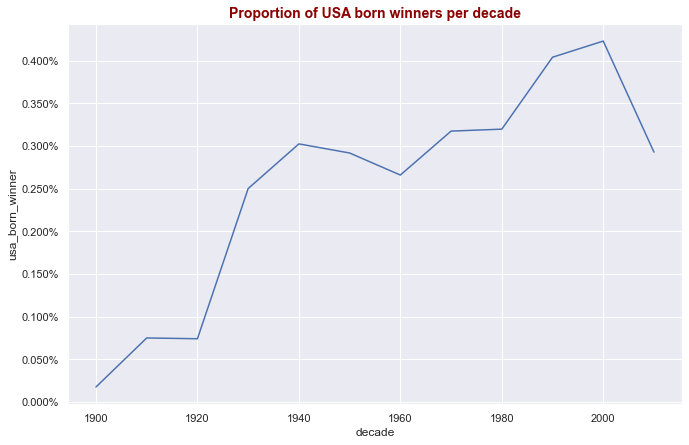

```python
# Setting the plotting theme
sns.set()

# and setting the size of all plots.
import matplotlib.pyplot as plt
import matplotlib.ticker as mtick
from matplotlib.ticker import PercentFormatter

plt.rcParams['figure.figsize'] = [11, 7]

# Plotting USA born winners
ax = sns.lineplot(data=prop_usa_winners, x='decade', y='usa_born_winner')

# Adding %-formatting to the y-axis
ax.yaxis.set_major_formatter(mtick.PercentFormatter())

# Adding more customizing
title_param    = {'color': 'darkred', 'fontsize': 14, 'weight': 'bold'}
plt.title('Proportion of USA born winners per decade', **title_param)
plt.show()
```

# Task 5: What is the gender of a typical Nobel Prize winner?

Plot the proportion of female laureates by decade split by prize category.

- Add the female_winner column to nobel, where the value is True when sex is "Female".
- Use groupby to group by both decade and category, setting as_index=False. Then isolate the female_winner column and take the mean(). Assign the resulting DataFrame to prop_female_winners.
- Copy and paste your seaborn plot from task 4 (including axis formatting code), but plot prop_female_winners and map the category variable to the hue parameter.

This task can be solved by copying and modifying the code from task 3 and 4.

> So the USA became the dominating winner of the Nobel Prize first in the 1930s and had kept the leading position ever since. But one group that was in the lead from the start, and never seems to let go, are men. Maybe it shouldn't come as a shock that there is some imbalance between how many male and female prize winners there are, but how significant is this imbalance? And is it better or worse within specific prize categories like physics, medicine, literature, etc.?

```python
# Calculating the proportion of female laureates per decade
nobel['female_winner'] = (nobel.sex == 'Female')
prop_female_winners = nobel.groupby(['decade', 'category'], as_index=False).female_winner.mean()
prop_female_winners.head()
```

|  | decade | category | female_winner |
| --- | --- | --- | --- |
| 0 | 1900 | Chemistry | 0.000000 |
| 1 | 1900 | Literature | 0.100000 |
| 2 | 1900 | Medicine | 0.000000 |
| 3 | 1900 | Peace | 0.071429 |
| 4 | 1900 | Physics | 0.076923 |

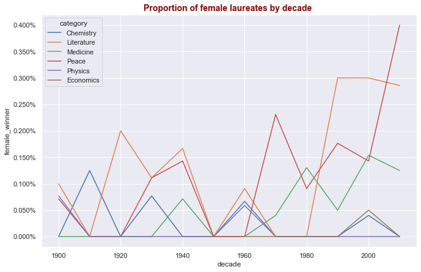

```python
# Plotting USA born winners with % winners on the y-axis
plt.rcParams['figure.figsize'] = [11, 7]
ax = sns.lineplot(data=prop_female_winners, x='decade', y='female_winner', hue='category')

# Adding %-formatting to the y-axis
ax.yaxis.set_major_formatter(mtick.PercentFormatter())

# Adding more customizing
title_param    = {'color': 'darkred', 'fontsize': 14, 'weight': 'bold'}
plt.title('Proportion of female laureates by decade ', **title_param)
plt.show()
```

# Task 6: The first woman to win the Nobel Prize

Extract and display the row showing the first woman to win a Nobel Prize.

- Select only the rows of 'Female' winners in nobel.
- Using the nsmallest() method with its n and columns parameters, pick out the first woman to get a Nobel Prize.

**Note**: a test in this task relies on the expected last output of this cell based on the order of the instructions. If this is not the case, you may run into the following error after ten seconds of the cell being processed: "Your code exceeded the maximum run time permitted."

See [here](https://pandas.pydata.org/pandas-docs/stable/generated/pandas.DataFrame.nsmallest.html) for the documentation of nsmallest().

> The plot above is a bit messy as the lines are overplotting. But it does show some interesting trends and patterns. Overall the imbalance is pretty large with physics, economics, and chemistry having the largest imbalance. Medicine has a somewhat positive trend, and since the 1990s the literature prize is also now more balanced. The big outlier is the peace prize during the 2010s, but keep in mind that this just covers the years 2010 to 2016.

> Given this imbalance, **who was the first woman to receive a Nobel Prize? And in what category?**

```python
# Picking out the first woman to win a Nobel Prize
nobel[nobel.sex=='Female'].nsmallest(1, 'year')
```

|  | year | category | prize | motivation | prize_share | laureate_id | laureate_type | full_name | birth_date | birth_city | ... | sex | organization_name | organization_city | organization_country | death_date | death_city | death_country | usa_born_winner | decade | female_winner |
| --- | --- | --- | --- | --- | --- | --- | --- | --- | --- | --- | --- | --- | --- | --- | --- | --- | --- | --- | --- | --- | --- |
| 19 | 1903 | Physics | The Nobel Prize in Physics 1903 | "in recognition of the extraordinary services ... | 1/4 | 6 | Individual | Marie Curie, née Sklodowska | 1867-11-07 | Warsaw | ... | Female | NaN | NaN | NaN | 1934-07-04 | Sallanches | France | False | 1900 | True |

1 rows × 21 columns

# Task 7: Repeat laureates

Extract and display the rows of repeat Nobel Prize winners.

- Use groupby to group nobel by 'full_name'.
- Use the filter method to keep only those rows in nobel with winners with 2 or more prizes.

**Note**: a test in this task relies on the expected last output of this cell based on the order of the instructions. If this is not the case, you may run into the following error after ten seconds of the cell being processed: "Your code exceeded the maximum run time permitted."

See [here](http://pandas.pydata.org/pandas-docs/stable/groupby.html#filtration) for how to use the filter method.

> For most scientists/writers/activists a Nobel Prize would be the crowning achievement of a long career. But for some people, one is just not enough, and few have gotten it more than once. Who are these lucky few? (Having won no Nobel Prize myself, I'll assume it's just about luck.)

```python
# Selecting the laureates that have received 2 or more prizes.
nobel.groupby('full_name').filter(lambda x: x['prize'].count() >= 2)
```

|  | year | category | prize | motivation | prize_share | laureate_id | laureate_type | full_name | birth_date | birth_city | ... | sex | organization_name | organization_city | organization_country | death_date | death_city | death_country | usa_born_winner | decade | female_winner |
| --- | --- | --- | --- | --- | --- | --- | --- | --- | --- | --- | --- | --- | --- | --- | --- | --- | --- | --- | --- | --- | --- |
| 19 | 1903 | Physics | The Nobel Prize in Physics 1903 | "in recognition of the extraordinary services ... | 1/4 | 6 | Individual | Marie Curie, née Sklodowska | 1867-11-07 | Warsaw | ... | Female | NaN | NaN | NaN | 1934-07-04 | Sallanches | France | False | 1900 | True |
| 62 | 1911 | Chemistry | The Nobel Prize in Chemistry 1911 | "in recognition of her services to the advance... | 1/1 | 6 | Individual | Marie Curie, née Sklodowska | 1867-11-07 | Warsaw | ... | Female | Sorbonne University | Paris | France | 1934-07-04 | Sallanches | France | False | 1910 | True |
| 89 | 1917 | Peace | The Nobel Peace Prize 1917 | NaN | 1/1 | 482 | Organization | Comité international de la Croix Rouge (Intern... | NaN | NaN | ... | NaN | NaN | NaN | NaN | NaN | NaN | NaN | False | 1910 | False |
| 215 | 1944 | Peace | The Nobel Peace Prize 1944 | NaN | 1/1 | 482 | Organization | Comité international de la Croix Rouge (Intern... | NaN | NaN | ... | NaN | NaN | NaN | NaN | NaN | NaN | NaN | False | 1940 | False |
| 278 | 1954 | Chemistry | The Nobel Prize in Chemistry 1954 | "for his research into the nature of the chemi... | 1/1 | 217 | Individual | Linus Carl Pauling | 1901-02-28 | Portland, OR | ... | Male | California Institute of Technology (Caltech) | Pasadena, CA | United States of America | 1994-08-19 | Big Sur, CA | United States of America | True | 1950 | False |
| 283 | 1954 | Peace | The Nobel Peace Prize 1954 | NaN | 1/1 | 515 | Organization | Office of the United Nations High Commissioner... | NaN | NaN | ... | NaN | NaN | NaN | NaN | NaN | NaN | NaN | False | 1950 | False |
| 298 | 1956 | Physics | The Nobel Prize in Physics 1956 | "for their researches on semiconductors and th... | 1/3 | 66 | Individual | John Bardeen | 1908-05-23 | Madison, WI | ... | Male | University of Illinois | Urbana, IL | United States of America | 1991-01-30 | Boston, MA | United States of America | True | 1950 | False |
| 306 | 1958 | Chemistry | The Nobel Prize in Chemistry 1958 | "for his work on the structure of proteins, es... | 1/1 | 222 | Individual | Frederick Sanger | 1918-08-13 | Rendcombe | ... | Male | University of Cambridge | Cambridge | United Kingdom | 2013-11-19 | Cambridge | United Kingdom | False | 1950 | False |
| 340 | 1962 | Peace | The Nobel Peace Prize 1962 | NaN | 1/1 | 217 | Individual | Linus Carl Pauling | 1901-02-28 | Portland, OR | ... | Male | California Institute of Technology (Caltech) | Pasadena, CA | United States of America | 1994-08-19 | Big Sur, CA | United States of America | True | 1960 | False |
| 348 | 1963 | Peace | The Nobel Peace Prize 1963 | NaN | 1/2 | 482 | Organization | Comité international de la Croix Rouge (Intern... | NaN | NaN | ... | NaN | NaN | NaN | NaN | NaN | NaN | NaN | False | 1960 | False |
| 424 | 1972 | Physics | The Nobel Prize in Physics 1972 | "for their jointly developed theory of superco... | 1/3 | 66 | Individual | John Bardeen | 1908-05-23 | Madison, WI | ... | Male | University of Illinois | Urbana, IL | United States of America | 1991-01-30 | Boston, MA | United States of America | True | 1970 | False |
| 505 | 1980 | Chemistry | The Nobel Prize in Chemistry 1980 | "for their contributions concerning the determ... | 1/4 | 222 | Individual | Frederick Sanger | 1918-08-13 | Rendcombe | ... | Male | MRC Laboratory of Molecular Biology | Cambridge | United Kingdom | 2013-11-19 | Cambridge | United Kingdom | False | 1980 | False |
| 523 | 1981 | Peace | The Nobel Peace Prize 1981 | NaN | 1/1 | 515 | Organization | Office of the United Nations High Commissioner... | NaN | NaN | ... | NaN | NaN | NaN | NaN | NaN | NaN | NaN | False | 1980 | False |

13 rows × 21 columns

# Task 8: How old are you when you get the prize?

Calculate and plot the age of each winner when they won their Nobel Prize.

- Convert the nobel['birth_date'] column to datetime using pd.to_datetime.
- Add a new column nobel['age'] that contains the age of each winner when they got the prize. That is, year of prize win minus birth year.
- Use sns.lmplot (not sns.lineplot) to make a plot with year on the x-axis and age on the y-axis.

**Note**: a test in this task relies on the expected last output of this cell based on the order of the instructions. If this is not the case, you may run into the following error after ten seconds of the cell being processed: "Your code exceeded the maximum run time permitted."

To get the year from a datetime column you need to use access the dt.year value. Here is an example:

`a_data_frame['a_datatime_column'].dt.year`

Seaborn's lmplot is a 2D scatterplot with an optional overlaid regression line. This type of plot is useful for [visualizing linear relationships](https://seaborn.pydata.org/tutorial/regression.html).

To make the plot prettier, add the arguments `lowess=True`, `aspect=2`, and `line_kws={'color' : 'black'}`.

> But how old are you generally when you get the prize?

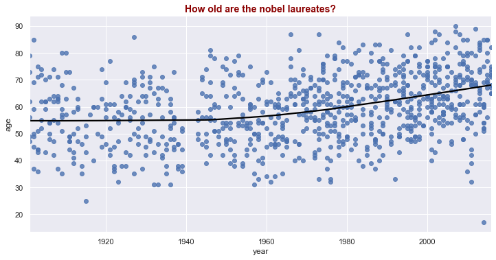

```python
# Converting birth_date from String to datetime
nobel['birth_date'] = pd.to_datetime(nobel['birth_date'])

# Calculating the age of Nobel Prize winners
nobel['age'] = nobel.year - nobel.birth_date.dt.year

# Plotting the age of Nobel Prize winners
title_param    = {'color': 'darkred', 'fontsize': 14, 'weight': 'bold'}
_ = sns.lmplot(data=nobel, x='year', y='age', lowess=True, aspect=2, line_kws={'color' : 'black'})
_ = plt.title('How old are the nobel laureates?', **title_param)
```

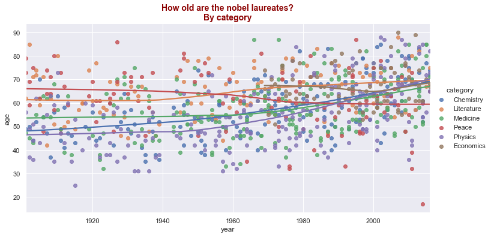

```python
# Plotting the age of Nobel Prize winners addign hue
title_param    = {'color': 'darkred', 'fontsize': 14, 'weight': 'bold'}
_ = sns.lmplot(data=nobel, x='year', y='age', hue='category', lowess=True, aspect=2)
_ = plt.title('How old are the nobel laureates?\nBy category', **title_param)
```

# Task 9: Age differences between prize categories

Plot how old winners are within the different price categories.

- As before, use sns.lmplot to make a plot with year on the x-axis and age on the y-axis. But this time, make one plot per prize category by setting the row argument to 'category'.

**Note**: a test in this task relies on the expected last output of this cell based on the order of the instructions. If this is not the case, you may run into the following error after ten seconds of the cell being processed: "Your code exceeded the maximum run time permitted."

This is the same plot as in task 8, except with the added row= argument (examples in the official Seaborn documentation [here](https://seaborn.pydata.org/generated/seaborn.lmplot.html)).

> The plot above shows us a lot! We see that people use to be around 55 when they received the price, but nowadays the average is closer to 65. But there is a large spread in the laureates' ages, and while most are 50+, some are very young.

> We also see that the density of points is much high nowadays than in the early 1900s -- nowadays many more of the prizes are shared, and so there are many more winners. We also see that there was a disruption in awarded prizes around the Second World War (1939 - 1945).

> Let's look at age trends within different prize categories.

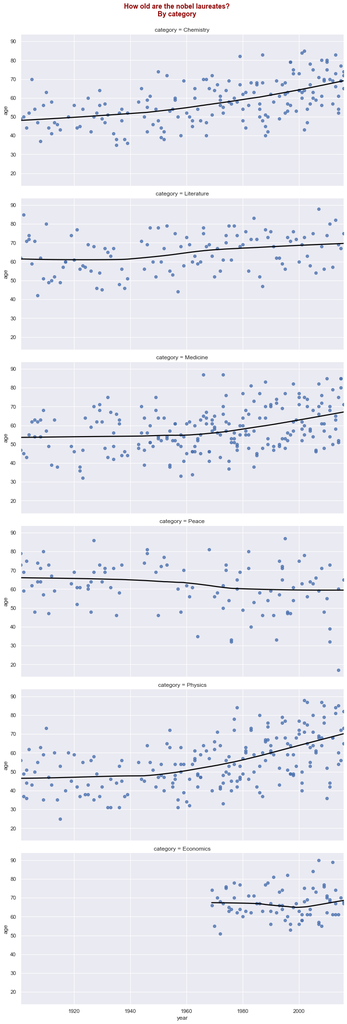

```python
# Same plot as above, but separate plots for each type of Nobel Prize
title_param    = {'color': 'darkred', 'fontsize': 14, 'weight': 'bold'}
_ = sns.lmplot(data=nobel, x='year', y='age', row='category', lowess=True, aspect=2, line_kws={'color' : 'black'})
_ = plt.suptitle('How old are the nobel laureates?\nBy category', **title_param)
plt.subplots_adjust(left=None, right=None, bottom=None, top=.95, hspace=None, wspace=None);
```

# Task 10: Oldest and youngest winners

Pick out the rows of the oldest and the youngest winner of a Nobel Prize.

- Use nlargest() to pick out and display the row of the oldest winner.
- Use nsmallest() to pick out and display the row of the youngest winner.

Note: a test in this task relies on the expected last output of this cell based on the order of the instructions. If this is not the case, you may run into the following error after ten seconds of the cell being processed: "Your code exceeded the maximum run time permitted."

As before, you will need to use display() to display more than the last output of the cell. Here is the documentation for [nsmallest](https://pandas.pydata.org/pandas-docs/stable/generated/pandas.DataFrame.nsmallest.html) and [n_largest](https://pandas.pydata.org/pandas-docs/stable/generated/pandas.DataFrame.nlargest.html).

> More plots with lots of exciting stuff going on! We see that both winners of the chemistry, medicine, and physics prize have gotten older over time. The trend is strongest for physics: the average age used to be below 50, and now it's almost 70. Literature and economics are more stable. We also see that economics is a newer category. But peace shows an opposite trend where winners are getting younger!

> In the peace category we also a winner around 2010 that seems exceptionally young. This begs the questions, who are the oldest and youngest people ever to have won a Nobel Prize?

```python
# The oldest winner of a Nobel Prize as of 2016
display(nobel.nlargest(1,'age'))

# The youngest winner of a Nobel Prize as of 2016
nobel.nsmallest(1, 'age')

#display(nobel.nsmallest(1, 'age')['full_name'].values[0])
#display(nobel.nsmallest(1, 'age').iat[0, 7])
#display(nobel.nsmallest(1, 'age').reset_index().at[0, 'full_name'])
```

|  | year | category | prize | motivation | prize_share | laureate_id | laureate_type | full_name | birth_date | birth_city | ... | organization_name | organization_city | organization_country | death_date | death_city | death_country | usa_born_winner | decade | female_winner | age |
| --- | --- | --- | --- | --- | --- | --- | --- | --- | --- | --- | --- | --- | --- | --- | --- | --- | --- | --- | --- | --- | --- |
| 793 | 2007 | Economics | The Sveriges Riksbank Prize in Economic Scienc... | "for having laid the foundations of mechanism ... | 1/3 | 820 | Individual | Leonid Hurwicz | 1917-08-21 | Moscow | ... | University of Minnesota | Minneapolis, MN | United States of America | 2008-06-24 | Minneapolis, MN | United States of America | False | 2000 | False | 90.0 |

1 rows × 22 columns

|  | year | category | prize | motivation | prize_share | laureate_id | laureate_type | full_name | birth_date | birth_city | ... | organization_name | organization_city | organization_country | death_date | death_city | death_country | usa_born_winner | decade | female_winner | age |
| --- | --- | --- | --- | --- | --- | --- | --- | --- | --- | --- | --- | --- | --- | --- | --- | --- | --- | --- | --- | --- | --- |
| 885 | 2014 | Peace | The Nobel Peace Prize 2014 | "for their struggle against the suppression of... | 1/2 | 914 | Individual | Malala Yousafzai | 1997-07-12 | Mingora | ... | NaN | NaN | NaN | NaN | NaN | NaN | False | 2010 | True | 17.0 |

1 rows × 22 columns

## Task 11: You get a prize!

- Assign the name of the youngest winner of a Nobel Prize to youngest_winner. The first name will suffice.

**If you want to know more**

The Nobel Prize dataset is rich, and this project just scratched the surface -- there is much more to explore! After you have completed this project, you can download it and continue exploring on your own! To do that you will have to install Jupyter Notebooks. Here are instructions for [how to install the Jupyter Notebook interface](http://jupyter.org/install.html). Good luck!

> Before you leave, what was again the name of the youngest winner ever who in 2014 got the prize for "[her] struggle against the suppression of children and young people and for the right of all children to education"?

```python
# The name of the youngest winner of the Nobel Prize as of 2016
youngest_winner = nobel.nsmallest(1, 'age')['full_name'].values[0]
youngest_winner
```

```
'Malala Yousafzai'
```

Congratulations, you passed all project tasks! Rate this project to finish...

# Aditional material

- Datacamp course:
  - https://learn.datacamp.com/projects/nobel-winners/guided/Python
  - https://projects.datacamp.com/projects/441
- Data source: https://www.kaggle.com/nobelfoundation/nobel-laureates